Este exercício é uma aplicação canônica de conceitos da inferência Bayesiana. Supomos uma pesquisa das cintenções de voto para um determinado candidato à prefeito da nossa Capital.

Na inferência Bayesiana buscamos conhecer a distribuição de probabilidade dos nossos parâmetros de interesse, a qual é produto da distribuição à priori com a verossimilhança dos dados, conforme:

$\begin{align} [\theta | y] \sim [ y | \theta ] . [ \theta ] \end{align}$ , onde:  
$\theta$ é parâmetro de interesse (ou vetor de parâmetros)  
$y$ são os dados

Vamos começar definindo nossa priori. Depois vamos analisar a verossimilhança dos dados de uma amostra deste tipo de dado e, então, construir nossa posteriori.

### Definição da priori

A priori será uma distribuição Beta por atender aos requisitos da variável: contónua com domínio $[0,1]$. $\begin{equation} [\theta] \sim \frac{ \Gamma(\alpha) \Gamma(\beta) }{\Gamma(\alpha+\beta)} \theta^{\alpha-1} (1-\theta)^{\beta-1} \end{equation}$

Por subjetividade, escolho que minha priori terá moda $0.525$ e que $95%$ da distribuição está entre os valores de $0.40$ e $0.65$. Utilizando as funções da dsitribuição Beta, vamos encontrar os parâmetros que dão essa forma à função.

```r
## Definition
mode <- 0.525
l.inf <- 0.4
l.sup <- 0.65

## Tryals
alpha <- seq(1, 50, length.out = 1e5)
beta <- ( (1-mode)*alpha + 2*mode - 1 ) / (mode)
p <- pbeta( l.sup, shape1 = alpha, shape2 = beta) - pbeta( l.inf, shape1 = alpha, shape2 = beta)
err <- abs(0.95-p)

## Best estimate
alpha <- alpha[which( err == min(err) )]
beta <- beta[which( err == min(err) )]
## Check it out
# pbeta(0.525, shape1 = alpha, shape2 = beta)
# pbeta( l.inf, shape1 = alpha, shape2 = beta)
# pbeta( l.sup, shape1 = alpha, shape2 = beta)
```

Com estes parâmetros, nossa priori tem a forma: $\begin{equation} [\theta] \sim Beta(\theta, \alpha=31.39, \beta=28.49) \end{equation}$

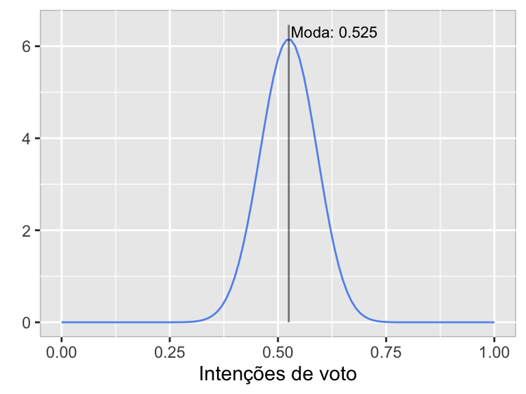

### Verossimilhança

Nossos dados fictícios constituem-se de uma amostra (suponha aleatória simples) de $n$ indivíduos cuja resposta é se tem ou não tem a insteção de votar no atual prefeito na eleição que ocorrerá este ano, caso ele seja candidato.

Logo, a distribuição dos nosso dados é uma Binomia: $\begin{align} y \sim Bin( \theta; n, k ) \\ \end{align}$ , onde: $\begin{align} Bin( \theta; n, k ) = \binom{n}{k} \theta^{k} (1-\theta)^{n-k} \\ \end{align}$

Vamos considerar $n=30$ e que destes $k=25$ disseram que votariam no candidato: $\begin{align} Bin( \theta; 30, 25 ) = \binom{30}{25} \theta^{25} (1-\theta)^{5} \\ \end{align}$

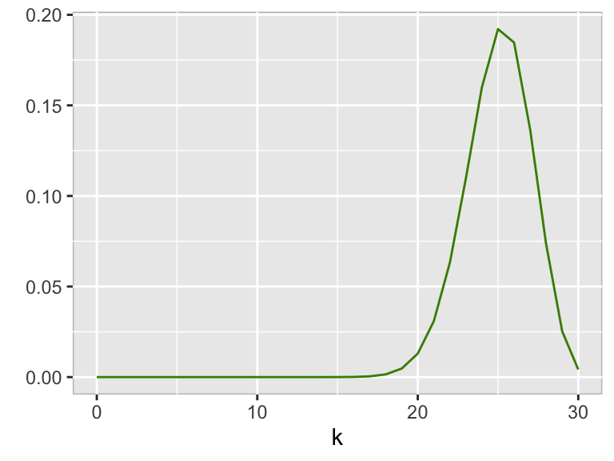

### Posteriori

O caso do nosso exemplo é de uma priori conjugada, cuja posteriori será uma atualização da priori pela verossimilhança. Provamos isso analisando as distribuições acima:

$\begin{equation} [\theta | y] \sim \binom{n}{k} \theta^{k} (1-\theta)^{n-k} ~ . ~ \frac{ \Gamma(\alpha) \Gamma(\beta) }{\Gamma(\alpha+\beta)} \theta^{\alpha-1} (1-\theta)^{\beta-1} \end{equation}$

A combinação $\binom{n}{k}$ e a fração de funções Gamma não dependem de $\theta$. Podemos, portanto tornar a equação acima proporcional: $\begin{equation} [\theta | y] \propto \theta^{k} (1-\theta)^{n-k} ~ . ~ \theta^{\alpha-1} (1-\theta)^{\beta-1} \end{equation}$

E agrupando os termos comuns: $\begin{equation} [\theta | y] \propto \theta^{k+\alpha-1} (1-\theta)^{n-k+\beta-1} \end{equation}$

Agora vemos que podemos reescrever os expoentes e chegar à parte da distribuição Beta dependente de *theta* novamente: $\begin{equation} [\theta | y] \propto \theta^{(\alpha+k)-1} (1-\theta)^{(\beta+n-k)-1} \end{equation}$

A qual pode, então ser reescrita como: $\begin{equation} [\theta | y] \propto Beta(\theta; \alpha^{*}, \beta^{*}) \end{equation}$ , onde: $\begin{align} \alpha^{*} & = \alpha + k \\ \beta^{*} & = \beta + (n-k) \\ \end{align}$

Repare, ainda que o $\alpha$ é atualizado pelo número de sucessos em nossa amostra, quanto o $\beta$, o é pelo número de fracassos.

Assim, teremos:

$\begin{align} \alpha^{*} & = 56.39 \\ \beta^{*} & = 33.49 \\ \end{align}$

E nosa posteriori será: $\begin{equation} [\theta] \sim Beta(\theta; \alpha=56.39, \beta=33.49) \end{equation}$

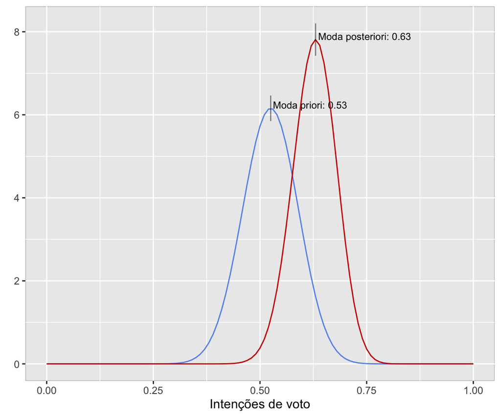